# Data Mining Assessment - Tim Durand

#### Model 4: Tuning

Three parameters were used in the grid search, these are described below:

- penalty (default=l2): Used to specify the norm used in the penalization. The newton-cg, sag and lbfgs solvers support only l2 penalties. elasticnet is only supported by the saga solver. If none (not supported by the liblinear solver), no regularization is applied.
- C (default=1.0): Inverse of regularization strength; must be a positive float. Like in support vector machines, smaller values specify stronger regularization.
- solver (default= lbfgs): Algorithm to use in the optimization problem. For small datasets, liblinear is a good choice, whereas sag and saga are faster for large ones.

```python
# Create the parameter grid based on the results of random search
param_grid = {
    'penalty' : ['l1', 'l2'],
    'C' : [0.001,0.01,0.1,1,10,100],
    'solver' : ['liblinear']
}

# Instantiate the grid search model
grid_search = GridSearchCV(estimator = lr, param_grid = param_grid,
                          cv = 3, n_jobs =-1)
# Fit the model against the grid of hyperparams
grid_search.fit(X_train,y_train)

print("Best Parameters:",grid_search.best_params_)
```

```
Best Parameters: {'C': 100, 'penalty': 'l1', 'solver': 'liblinear'}
```

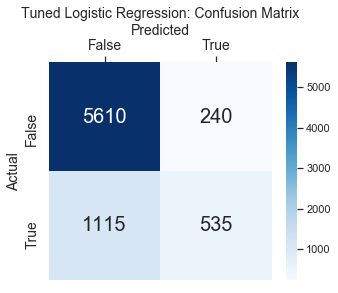

```
              precision    recall  f1-score   support

           0       0.83      0.96      0.89      5850
           1       0.69      0.32      0.44      1650

    accuracy                           0.82      7500
   macro avg       0.76      0.64      0.67      7500
weighted avg       0.80      0.82      0.79      7500
```

```python
lr_best_model = grid_search.best_estimator_
blr_preds = lr_best_model.predict(X_test)
# confusion matrix
blr_cm = pd.DataFrame(confusion_matrix(y_test, blr_preds), columns=np.unique(y_test), index = np.unique(y_test))
blr_cm.index.name = 'Actual'
blr_cm.columns.name = 'Predicted'

# Plot CM
plt.figure(figsize=(5,4))
ax= plt.subplot()
plt.title('Tuned Logistic Regression: Confusion Matrix', size=14)
sns.heatmap(blr_cm, annot=True, ax=ax, fmt = 'g',cmap='Blues', annot_kws={"size": 20});
ax.set_xlabel('Predicted', fontsize=14)
ax.xaxis.set_label_position('top')
ax.xaxis.set_ticklabels(['False', 'True'], fontsize = 14)
ax.xaxis.tick_top()
ax.set_ylabel('Actual', fontsize=14)
ax.yaxis.set_ticklabels(['False', 'True'], fontsize = 14)
plt.show()
print(classification_report(y_test, blr_preds))
```

This model provides results comparable to the Random forest, both in low False Positive numbers and overall accuracy.

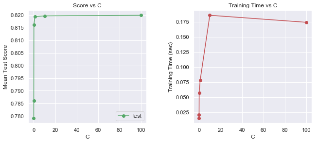

```python
# Create the parameter grid based on the results of random search
param_grid = {
    'penalty' : ['l1'],
    #'C' : np.logspace(-4, 4, 20),
    'C' : [0.001,0.01,0.1,1,10,100],
    'solver' : ['liblinear']
}

# Instantiate the grid search model
grid_search = GridSearchCV(estimator = lr, param_grid = param_grid,
                          cv = 3, n_jobs =-1)
# Fit the model against the grid of hyperparams
grid_search.fit(X_train,y_train)
a.plot_grid_results(grid_search, param='C', name = 'C')
```

Smaller values of C, increase the strength of regularization, this creates a simple model which can under-fit the data. Large values of C allow a model to increase it's complexity, and therefore, potential over-fitting can occur. One can see from the above variable values of C that the optimum level is relatively low, although the grid search identified 100 as the best value, increasing C beyond 10 does not increase the score vastly and may lead to over-fitting. Due to the simplicity of the model the training time is low compared to other models.

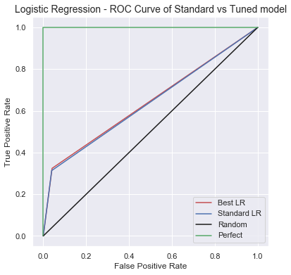

```python
# ROC
fpr_blr, tpr_blr, thresholds_blr = roc_curve(y_test, blr_preds)
fpr_lr, tpr_lr, thresholds_lr = roc_curve(y_test, lr_preds)
plt.rcParams['figure.figsize'] = [6,6]
plt.plot(fpr_blr, tpr_blr,'r-',label = 'Best LR')
plt.plot(fpr_lr,tpr_lr,'b-', label= 'Standard LR')
plt.plot([0,1],[0,1],'k-',label='Random')
plt.plot([0,0,1,1],[0,1,1,1],'g-',label='Perfect')
plt.legend()
plt.xlabel('False Positive Rate')
plt.ylabel('True Positive Rate')
plt.title("Logistic Regression - ROC Curve of Standard vs Tuned model", size="14")
plt.show()
```

One can see from the above that only a small improvement in the ROC curve is obtained with the tuned model, ROC curves can be useful but they don't tell the whole story.

### Unequal Costs

The unequal cost models were evaluated from an overall cost perspective rather than their respective accuracy scores. The imblearn library was used for cost sensitive modeling, the costcla library was also tried but the models did not seem to work well, and the documentation a little vague. The same model types were used in the balanced and unbalanced tasks. The process for each model type, was to compare the default cost sensitive model, with the default equal cost model before tuning the cost sensitive model and comparing the results with its equal costs, tuned, counterpart.

#### Cost Matrix

```python
# Create Cost Matrix
costmatrix = pd.DataFrame([[0,1],[5,0]], columns=['False','True' ],index=['False','True' ])
display(costmatrix.style.set_table_styles(dfstyles).set_caption('Cost Matrix'))
```

Cost Matrix

|  | False | True |
| --- | --- | --- |
| False | 0 | 1 |
| True | 5 | 0 |

The cost of misclassifying an actual defaulting customer, is 5 times higher than misclassifying a non-defaulting customer; this is expressed in the above Cost Matrix.

#### Model 1: Cost Sensitive Decision Tree

The imblearn library did not have a basic Decision Tree, KNN or Logistic regression model; however it has a bagging classifier, where any sklearn model can be used as the base model. Bagging refers to bootstrap aggregation, based on the principle that multiple weaker models can outperform a single stronger model. Variance is minimised which helps avoid over-fitting.

```python
csdt = BalancedBaggingClassifier(base_estimator= DecisionTreeClassifier(random_state= randomstate), random_state= randomstate, n_jobs=-1)
csdt.fit(np.array(X_train),np.array(y_train))
csdt_preds = csdt.predict(X_test)
# confusion matrix
csdt_cm = pd.DataFrame(confusion_matrix(y_test, csdt_preds), columns=np.unique(y_test), index = np.unique(y_test))
csdt_cm.index.name = 'Actual'
csdt_cm.columns.name = 'Predicted'

csdt_cost = a.computecost(csdt_cm)
dt_cost = a.computecost(dt_cm)
```

```
Cost Sensitive Decision Tree Cost =  5006
Decision Tree Cost =  5980
```

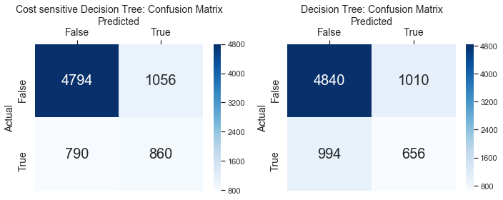

```python
fig, axes = plt.subplots(1, 2,figsize=(10,4))
axes = axes.flatten()

sns.heatmap(csdt_cm, annot=True, ax=axes[0], fmt = 'g',cmap='Blues', annot_kws={"size": 20}).set_title("Cost sensitive Decision Tree: Confusion Matrix", size = 14)
axes[0].set_xlabel('Predicted', fontsize=14)
axes[0].xaxis.set_label_position('top')
axes[0].xaxis.set_ticklabels(['False', 'True'], fontsize = 14)
axes[0].xaxis.tick_top()
axes[0].set_ylabel('Actual', fontsize=14)
axes[0].yaxis.set_ticklabels(['False', 'True'], fontsize = 14)

sns.heatmap(dt_cm, annot=True, ax=axes[1], fmt = 'g',cmap='Blues', annot_kws={"size": 20}).set_title("Decision Tree: Confusion Matrix", size = 14)
axes[1].set_xlabel('Predicted', fontsize=14)
axes[1].xaxis.set_label_position('top')
axes[1].xaxis.set_ticklabels(['False', 'True'], fontsize = 14)
axes[1].xaxis.tick_top()
axes[1].set_ylabel('Actual', fontsize=14)
axes[1].yaxis.set_ticklabels(['False', 'True'], fontsize = 14)
plt.tight_layout()
print('Cost Sensitive Decision Tree Cost = ',csdt_cost.values.sum())
print('Decision Tree Cost = ',dt_cost.values.sum())
```

The cost sensitive decision tree reduced the number of False Negatives compared with the regular decision tree, making the cost of the model around 16% lower.

#### Model 1: Tuning

```python
# Create the parameter grid
param_grid = {
    'base_estimator__max_depth': [3, 5, 10, 20, 30, 50, 70, 100, 140],
    'base_estimator__max_features': [None, "auto", 2, 3, 4],
    'base_estimator__min_samples_leaf': [1, 2, 3, 4, 5],
    'base_estimator__min_samples_split': [2, 4, 8, 10, 12]
}

# Instantiate the grid search model
grid_search = GridSearchCV(estimator = csdt, param_grid = param_grid,
                          cv = 3, n_jobs =-1)
# Fit the model against the grid of hyperparams
grid_search.fit(X_train,y_train)

print("Best Parameters:",grid_search.best_params_)

csdt_best_model = grid_search.best_estimator_
bcsdt_preds = csdt_best_model.predict(X_test)

# confusion matrix
bcsdt_cm = pd.DataFrame(confusion_matrix(y_test, bcsdt_preds), columns=np.unique(y_test), index = np.unique(y_test))
bcsdt_cm.index.name = 'Actual'
bcsdt_cm.columns.name = 'Predicted'

bcsdt_cost = a.computecost(bcsdt_cm)
bdt_cost = a.computecost(bdt_cm)
```

```
Best Parameters: {'base_estimator__max_depth': 30, 'base_estimator__max_features': 4, 'base_estimator__min_samples_leaf': 1, 'base_estimator__min_samples_split': 2}
```

```
Tuned Cost Sensitive Decision Tree: Cost =  4945
Tuned Decision Tree: Cost =  5920
```

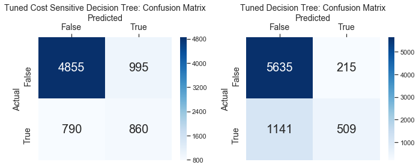

```python
fig, axes = plt.subplots(1, 2,figsize=(10,4))
axes = axes.flatten()

sns.heatmap(bcsdt_cm, annot=True, ax=axes[0], fmt = 'g',cmap='Blues', annot_kws={"size": 20}).set_title("Tuned Cost Sensitive Decision Tree: Confusion Matrix", size = 14)
axes[0].set_xlabel('Predicted', fontsize=14)
axes[0].xaxis.set_label_position('top')
axes[0].xaxis.set_ticklabels(['False', 'True'], fontsize = 14)
axes[0].xaxis.tick_top()
axes[0].set_ylabel('Actual', fontsize=14)
axes[0].yaxis.set_ticklabels(['False', 'True'], fontsize = 14)

sns.heatmap(bdt_cm, annot=True, ax=axes[1], fmt = 'g',cmap='Blues', annot_kws={"size": 20}).set_title("Tuned Decision Tree: Confusion Matrix", size = 14)
axes[1].set_xlabel('Predicted', fontsize=14)
axes[1].xaxis.set_label_position('top')
axes[1].xaxis.set_ticklabels(['False', 'True'], fontsize = 14)
axes[1].xaxis.tick_top()
axes[1].set_ylabel('Actual', fontsize=14)
axes[1].yaxis.set_ticklabels(['False', 'True'], fontsize = 14)
plt.tight_layout()
print('Tuned Cost Sensitive Decision Tree: Cost = ',bcsdt_cost.values.sum())
print('Tuned Decision Tree: Cost = ',bdt_cost.values.sum())
```

The same parameters, as the unbalanced model, were used for tuning the balanced model; but the optimum depth of the tree is 30 as opposed to 3. The increased tree depth could mean a more complex model is required, to better predict the under represented target class.

#### Model 2: Cost Sensitive Random Forest

```python
csrf = BalancedRandomForestClassifier(random_state= randomstate)
csrf.fit(np.array(X_train),np.array(y_train))
csrf_preds = csrf.predict(X_test)
# confusion matrix
csrf_cm = pd.DataFrame(confusion_matrix(y_test, csrf_preds), columns=np.unique(y_test), index = np.unique(y_test))
csrf_cm.index.name = 'Actual'
csrf_cm.columns.name = 'Predicted'

csrf_cost = a.computecost(csrf_cm)
rf_cost = a.computecost(rf_cm)
```

```
Cost Sensitive Random Forest: Cost =  4429
Random Forest Cost =  5625
```

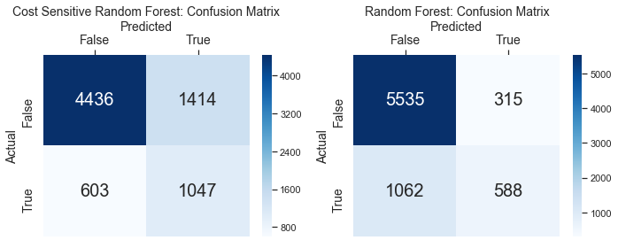

```python
fig, axes = plt.subplots(1, 2,figsize=(10,4))
axes = axes.flatten()

sns.heatmap(csrf_cm, annot=True, ax=axes[0], fmt = 'g',cmap='Blues', annot_kws={"size": 20}).set_title("Cost Sensitive Random Forest: Confusion Matrix", size = 14)
axes[0].set_xlabel('Predicted', fontsize=14)
axes[0].xaxis.set_label_position('top')
axes[0].xaxis.set_ticklabels(['False', 'True'], fontsize = 14)
axes[0].xaxis.tick_top()
axes[0].set_ylabel('Actual', fontsize=14)
axes[0].yaxis.set_ticklabels(['False', 'True'], fontsize = 14)

sns.heatmap(rf_cm, annot=True, ax=axes[1], fmt = 'g',cmap='Blues', annot_kws={"size": 20}).set_title("Random Forest: Confusion Matrix", size = 14)
axes[1].set_xlabel('Predicted', fontsize=14)
axes[1].xaxis.set_label_position('top')
axes[1].xaxis.set_ticklabels(['False', 'True'], fontsize = 14)
axes[1].xaxis.tick_top()
axes[1].set_ylabel('Actual', fontsize=14)
axes[1].yaxis.set_ticklabels(['False', 'True'], fontsize = 14)
plt.tight_layout()
print('Cost Sensitive Random Forest: Cost = ',csrf_cost.values.sum())
print('Random Forest Cost = ',rf_cost.values.sum())
```

False Positives were much more prevalent in the cost sensitive random forest, but False Negatives, which carries a much higher cost penalty, were around 40% less leading to a lower cost model.

#### Model 2: Tuning

```python
# Create the parameter grid
param_grid = {
    'max_depth': [5, 10, 15],
    'max_features': ["auto", 2, 4],
    'min_samples_leaf': [1, 2, 3, 5],
    'min_samples_split': [2, 4],
    'n_estimators': [80, 90, 100]
}

# Instantiate the grid search model
grid_search = GridSearchCV(estimator = csrf, param_grid = param_grid,
                          cv = 3, n_jobs =-1)
# Fit the model against the grid of hyperparams
grid_search.fit(X_train,y_train)

print("Best Parameters:",grid_search.best_params_)

csrf_best_model = grid_search.best_estimator_
bcsrf_preds = csrf_best_model.predict(X_test)

# confusion matrix
bcsrf_cm = pd.DataFrame(confusion_matrix(y_test, bcsrf_preds), columns=np.unique(y_test), index = np.unique(y_test))
bcsrf_cm.index.name = 'Actual'
bcsrf_cm.columns.name = 'Predicted'

bcsrf_cost = a.computecost(bcsrf_cm)
brf_cost = a.computecost(brf_cm)
```

```
Best Parameters: {'max_depth': 10, 'max_features': 2, 'min_samples_leaf': 5, 'min_samples_split': 2, 'n_estimators': 100}
```

```
Tuned, Cost Sensitive, Random Forest: Cost =  4381
Tuned, Random Forest: Cost =  5625
```

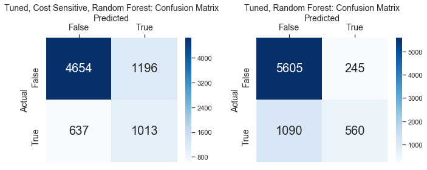

```python
fig, axes = plt.subplots(1, 2,figsize=(10,4))
axes = axes.flatten()

sns.heatmap(bcsrf_cm, annot=True, ax=axes[0], fmt = 'g',cmap='Blues', annot_kws={"size": 20}).set_title("Tuned, Cost Sensitive, Random Forest: Confusion Matrix", size = 14)
axes[0].set_xlabel('Predicted', fontsize=14)
axes[0].xaxis.set_label_position('top')
axes[0].xaxis.set_ticklabels(['False', 'True'], fontsize = 14)
axes[0].xaxis.tick_top()
axes[0].set_ylabel('Actual', fontsize=14)
axes[0].yaxis.set_ticklabels(['False', 'True'], fontsize = 14)

sns.heatmap(brf_cm, annot=True, ax=axes[1], fmt = 'g',cmap='Blues', annot_kws={"size": 20}).set_title("Tuned, Random Forest: Confusion Matrix", size = 14)
axes[1].set_xlabel('Predicted', fontsize=14)
axes[1].xaxis.set_label_position('top')
axes[1].xaxis.set_ticklabels(['False', 'True'], fontsize = 14)
axes[1].xaxis.tick_top()
axes[1].set_ylabel('Actual', fontsize=14)
axes[1].yaxis.set_ticklabels(['False', 'True'], fontsize = 14)
plt.tight_layout()
print('Tuned, Cost Sensitive, Random Forest: Cost = ',bcsrf_cost.values.sum())
print('Tuned, Random Forest: Cost = ',rf_cost.values.sum())
```

The best parameter set, output by the grid search, for the equal/unequal cost models, is very similar. The min_samples_leaf is higher; this parameter defines the minimum number of samples required to be at a leaf node; a higher value means an increase in bias and a decrease in variance, which may cause over-fitting.

#### Model 3: Balanced Bagging with KNN

```python
csknn = BalancedBaggingClassifier(base_estimator= KNeighborsClassifier(), random_state= randomstate, n_jobs=-1)
csknn.fit(np.array(X_train),np.array(y_train))
csknn_preds = csknn.predict(X_test)
# confusion matrix
csknn_cm = pd.DataFrame(confusion_matrix(y_test, csknn_preds), columns=np.unique(y_test), index = np.unique(y_test))
csknn_cm.index.name = 'Actual'
csknn_cm.columns.name = 'Predicted'

csknn_cost = a.computecost(csknn_cm)
knn_cost = a.computecost(knn_cm)
```

```
Cost Sensitive, KNN: Cost =  4626
KNN Cost =  5697
```

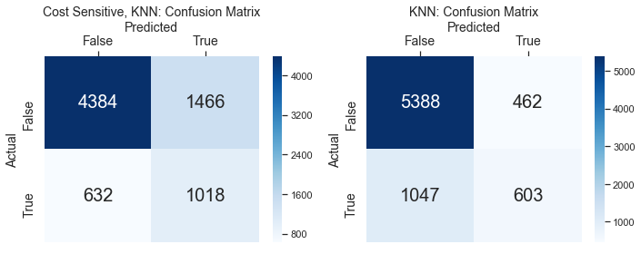

```python
fig, axes = plt.subplots(1, 2,figsize=(10,4))
axes = axes.flatten()

sns.heatmap(csknn_cm, annot=True, ax=axes[0], fmt = 'g',cmap='Blues', annot_kws={"size": 20}).set_title("Cost Sensitive, KNN: Confusion Matrix", size = 14)
axes[0].set_xlabel('Predicted', fontsize=14)
axes[0].xaxis.set_label_position('top')
axes[0].xaxis.set_ticklabels(['False', 'True'], fontsize = 14)
axes[0].xaxis.tick_top()
axes[0].set_ylabel('Actual', fontsize=14)
axes[0].yaxis.set_ticklabels(['False', 'True'], fontsize = 14)

sns.heatmap(knn_cm, annot=True, ax=axes[1], fmt = 'g',cmap='Blues', annot_kws={"size": 20}).set_title("KNN: Confusion Matrix", size = 14)
axes[1].set_xlabel('Predicted', fontsize=14)
axes[1].xaxis.set_label_position('top')
axes[1].xaxis.set_ticklabels(['False', 'True'], fontsize = 14)
axes[1].xaxis.tick_top()
axes[1].set_ylabel('Actual', fontsize=14)
axes[1].yaxis.set_ticklabels(['False', 'True'], fontsize = 14)
plt.tight_layout()
print('Cost Sensitive, KNN: Cost = ',csknn_cost.values.sum())
print('KNN Cost = ',knn_cost.values.sum())
```

The confusion matrix above, shows that the accuracy of the balanced model is significantly lower than the original model, but the lower number of False Negatives, with a cost multiplier of 5, lowered the overall cost.

#### Model 3: Tuning

```python
# Create the parameter grid
param_grid = {
    'base_estimator__n_neighbors': [3,5,7,9,11,13,15,17]
}

# Instantiate the grid search model
grid_search = GridSearchCV(estimator = csknn, param_grid = param_grid,
                          cv = 3, n_jobs =-1)
# Fit the model against the grid of hyperparams
grid_search.fit(X_train,y_train)

print("Best Parameters:",grid_search.best_params_)

csknn_best_model = grid_search.best_estimator_
bcsknn_preds = csknn_best_model.predict(X_test)

# confusion matrix
bcsknn_cm = pd.DataFrame(confusion_matrix(y_test, bcsknn_preds), columns=np.unique(y_test), index = np.unique(y_test))
bcsknn_cm.index.name = 'Actual'
bcsknn_cm.columns.name = 'Predicted'

bcsknn_cost = a.computecost(bcsknn_cm)
bknn_cost = a.computecost(bknn_cm)
```

```
Best Parameters: {'base_estimator__n_neighbors': 17}
```

```
Tuned, Cost Sensative KNN: Cost =  4549
Tuned, KNN: Cost =  5647
```

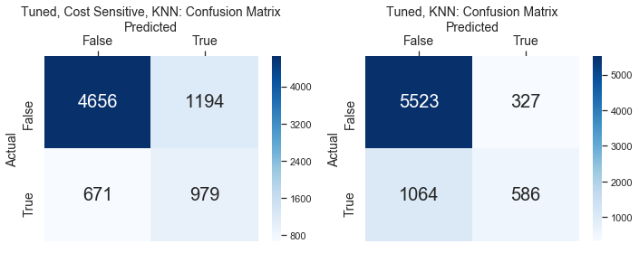

```python
fig, axes = plt.subplots(1, 2,figsize=(10,4))
axes = axes.flatten()

sns.heatmap(bcsknn_cm, annot=True, ax=axes[0], fmt = 'g',cmap='Blues', annot_kws={"size": 20}).set_title("Tuned, Cost Sensitive, KNN: Confusion Matrix", size = 14)
axes[0].set_xlabel('Predicted', fontsize=14)
axes[0].xaxis.set_label_position('top')
axes[0].xaxis.set_ticklabels(['False', 'True'], fontsize = 14)
axes[0].xaxis.tick_top()
axes[0].set_ylabel('Actual', fontsize=14)
axes[0].yaxis.set_ticklabels(['False', 'True'], fontsize = 14)

sns.heatmap(bknn_cm, annot=True, ax=axes[1], fmt = 'g',cmap='Blues', annot_kws={"size": 20}).set_title("Tuned, KNN: Confusion Matrix", size = 14)
axes[1].set_xlabel('Predicted', fontsize=14)
axes[1].xaxis.set_label_position('top')
axes[1].xaxis.set_ticklabels(['False', 'True'], fontsize = 14)
axes[1].xaxis.tick_top()
axes[1].set_ylabel('Actual', fontsize=14)
axes[1].yaxis.set_ticklabels(['False', 'True'], fontsize = 14)
plt.tight_layout()
print('Tuned, Cost Sensative KNN: Cost = ',bcsknn_cost.values.sum())
print('Tuned, KNN: Cost = ',bknn_cost.values.sum())
```

#### Model 4: Cost Sensitive Logistic Regression

```python
cslr = BalancedBaggingClassifier(base_estimator= LogisticRegression(), random_state= randomstate, n_jobs=-1)
cslr.fit(np.array(X_train),np.array(y_train))
cslr_preds = cslr.predict(X_test)
# confusion matrix
cslr_cm = pd.DataFrame(confusion_matrix(y_test, cslr_preds), columns=np.unique(y_test), index = np.unique(y_test))
cslr_cm.index.name = 'Actual'
cslr_cm.columns.name = 'Predicted'

cslr_cost = a.computecost(cslr_cm)
lr_cost = a.computecost(lr_cm)
```

```
Cost Sensitive, Logistic Regression: Cost =  4630
Logistic Regression: Cost =  5894
```

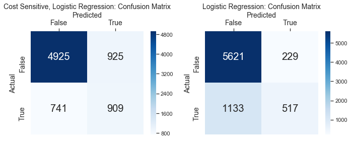

```python
fig, axes = plt.subplots(1, 2,figsize=(10,4))
axes = axes.flatten()

sns.heatmap(cslr_cm, annot=True, ax=axes[0], fmt = 'g',cmap='Blues', annot_kws={"size": 20}).set_title("Cost Sensitive, Logistic Regression: Confusion Matrix", size = 14)
axes[0].set_xlabel('Predicted', fontsize=14)
axes[0].xaxis.set_label_position('top')
axes[0].xaxis.set_ticklabels(['False', 'True'], fontsize = 14)
axes[0].xaxis.tick_top()
axes[0].set_ylabel('Actual', fontsize=14)
axes[0].yaxis.set_ticklabels(['False', 'True'], fontsize = 14)

sns.heatmap(lr_cm, annot=True, ax=axes[1], fmt = 'g',cmap='Blues', annot_kws={"size": 20}).set_title("Logistic Regression: Confusion Matrix", size = 14)
axes[1].set_xlabel('Predicted', fontsize=14)
axes[1].xaxis.set_label_position('top')
axes[1].xaxis.set_ticklabels(['False', 'True'], fontsize = 14)
axes[1].xaxis.tick_top()
axes[1].set_ylabel('Actual', fontsize=14)
axes[1].yaxis.set_ticklabels(['False', 'True'], fontsize = 14)
plt.tight_layout()
print('Cost Sensitive, Logistic Regression: Cost = ',cslr_cost.values.sum())
print('Logistic Regression: Cost = ',lr_cost.values.sum())
```

#### Model 4: Tuning

```python
# Create the parameter grid
param_grid = {
    'base_estimator__penalty' : ['l1', 'l2'],
    'base_estimator__C' : [0.001,0.01,0.1,1,10,100],
    'base_estimator__solver' : ['liblinear']
}

# Instantiate the grid search model
grid_search = GridSearchCV(estimator = cslr, param_grid = param_grid,
                          cv = 3, n_jobs =-1)
# Fit the model against the grid of hyperparams
grid_search.fit(X_train,y_train)

print("Best Parameters:",grid_search.best_params_)

cslr_best_model = grid_search.best_estimator_
bcslr_preds = cslr_best_model.predict(X_test)

# confusion matrix
bcslr_cm = pd.DataFrame(confusion_matrix(y_test, bcslr_preds), columns=np.unique(y_test), index = np.unique(y_test))
bcslr_cm.index.name = 'Actual'
bcslr_cm.columns.name = 'Predicted'

bcslr_cost = a.computecost(bcslr_cm)
blr_cost = a.computecost(blr_cm)
```

```
Best Parameters: {'base_estimator__C': 0.1, 'base_estimator__penalty': 'l2', 'base_estimator__solver': 'liblinear'}
```

```
Tuned, Cost Sensitive, Logistic Regression: Cost =  4664
Tuned, Logistic Regression: Cost =  5815
```

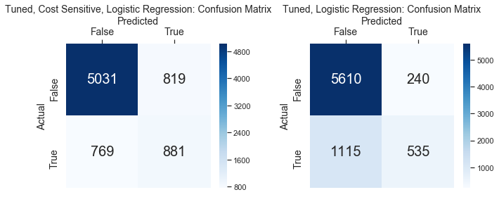

```python
fig, axes = plt.subplots(1, 2,figsize=(10,4))
axes = axes.flatten()

sns.heatmap(bcslr_cm, annot=True, ax=axes[0], fmt = 'g',cmap='Blues', annot_kws={"size": 20}).set_title("Tuned, Cost Sensitive, Logistic Regression: Confusion Matrix", size = 14)
axes[0].set_xlabel('Predicted', fontsize=14)
axes[0].xaxis.set_label_position('top')
axes[0].xaxis.set_ticklabels(['False', 'True'], fontsize = 14)
axes[0].xaxis.tick_top()
axes[0].set_ylabel('Actual', fontsize=14)
axes[0].yaxis.set_ticklabels(['False', 'True'], fontsize = 14)

sns.heatmap(blr_cm, annot=True, ax=axes[1], fmt = 'g',cmap='Blues', annot_kws={"size": 20}).set_title("Tuned, Logistic Regression: Confusion Matrix", size = 14)
axes[1].set_xlabel('Predicted', fontsize=14)
axes[1].xaxis.set_label_position('top')
axes[1].xaxis.set_ticklabels(['False', 'True'], fontsize = 14)
axes[1].xaxis.tick_top()
axes[1].set_ylabel('Actual', fontsize=14)
axes[1].yaxis.set_ticklabels(['False', 'True'], fontsize = 14)
plt.tight_layout()
print('Tuned, Cost Sensitive, Logistic Regression: Cost = ',bcslr_cost.values.sum())
print('Tuned, Logistic Regression: Cost = ',blr_cost.values.sum())
```

The default and tuned cost sensitive models, both reduced the number of False Negatives providing, a lower overall cost than the equal cost models. The cost for the default cost sensitive model, is actually lower than the tuned model, this is due to the metric used in the grid search for finding the best model.

### Model Comparison

#### Equal Costs

Table: Accuracy Based Comparison

|  | Model | Accuracy | True Positive | True Negative |
| --- | --- | --- | --- | --- |
| 1 | Random Forest | 0.822 | 560 | 5605 |
| 3 | Logistic Regression | 0.819333 | 535 | 5610 |
| 0 | Decision Tree | 0.8192 | 509 | 5635 |
| 2 | KNN | 0.814533 | 586 | 5523 |

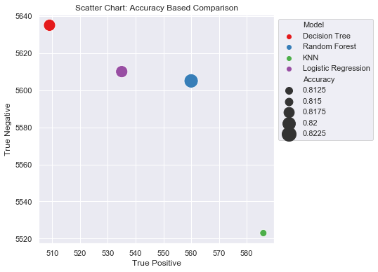

```python
cmdict = {'Decision Tree': bdt_cm, 'Random Forest': brf_cm, 'KNN' : bknn_cm, 'Logistic Regression': blr_cm}
def fn_fp_comp(x):
    tplist = []
    tnlist = []
    modellist = []
    acclist = []
    for k,v in x.items():
        tplist.append(v.iloc[1,1])
        tnlist.append(v.iloc[0,0])
        acclist.append((v.iloc[0,0]+ v.iloc[1,1])/ (v.values.sum()))
        modellist.append(k)
    return (pd.DataFrame({'Model':modellist, 'Accuracy':acclist, 'True Positive' : tplist, 'True Negative' : tnlist}))
costresults = fn_fp_comp(cmdict)
display(costresults.sort_values(by='Accuracy',ascending = False).style.set_table_styles(dfstyles).set_caption('Table: Accuracy Based Comparison'))

plt.figure(figsize=(6,6))
g = sns.scatterplot(x="True Positive", y="True Negative",hue="Model", data=costresults, palette="Set1", size = 'Accuracy',sizes=(100, 400)).set_title('Scatter Chart: Accuracy Based Comparison')
plt.legend(bbox_to_anchor=(1, 1), loc=2)
plt.show()
```

The accuracy, true positives, and true negatives for all tuned models are were collected and displayed above. The size of the point in the scatter chart denotes the accuracy, which is plot on the true positive/negative axes.

The information above, shows the best overall model from an accuracy perspective, is the Random Forest. The difference between the tuned models is relatively small, so it may be prudent to chose a simpler model from a computational perspective; Logistic Regression was chosen as the final model as it offered similar accuracy but less complexity. A simpler model may lead to a better result on the unseen test data due to less risk of over-fitting.

#### Unequal Costs

Table: Cost Sensitive Comparison

|  | Model | Cost | False Positive | False Negative | Accuracy |
| --- | --- | --- | --- | --- | --- |
| 1 | Random Forest | 4381 | 1196 | 637 | 0.7556 |
| 2 | KNN | 4549 | 1194 | 671 | 0.751333 |
| 3 | Logistic Regression | 4630 | 925 | 741 | 0.777867 |
| 0 | Decision Tree | 4945 | 995 | 790 | 0.762 |

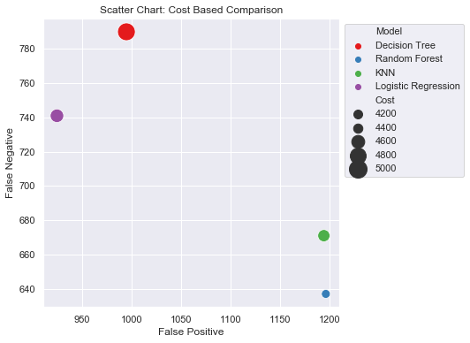

```python
cmdict = {'Decision Tree'  : bcsdt_cm, 'Random Forest'  : bcsrf_cm, 'KNN' : bcsknn_cm, 'Logistic Regression'  : cslr_cm}
def fn_fp_comp(x):
    fnlist = []
    fplist = []
    modellist = []
    costlist = []
    acclist = []
    for k,v in x.items():
        fplist.append(v.iloc[0,1])
        fnlist.append(v.iloc[1,0])
        costlist.append(v.iloc[0,1] + (v.iloc[1,0] * 5))
        acclist.append((v.iloc[0,0]+ v.iloc[1,1])/ (v.values.sum()))
        modellist.append(k)
    return (pd.DataFrame({'Model':modellist, 'Cost' : costlist, 'False Positive' : fplist, 'False Negative' : fnlist, 'Accuracy':acclist}))
costresults = fn_fp_comp(cmdict)
display(costresults.sort_values(by='Cost').style.set_table_styles(dfstyles).set_caption('Table: Cost Sensitive Comparison'))

plt.figure(figsize=(6,6))
sns.scatterplot(x="False Positive", y="False Negative",hue="Model", data=costresults, palette="Set1", size = 'Cost',sizes=(100, 400)).set_title('Scatter Chart: Cost Based Comparison')
plt.legend(bbox_to_anchor=(1, 1), loc=2)
plt.show()
```

The best model from a cost perspective, is again, the Random Forest. The un-tuned Logistic Regression model is shown above, as this had less overall cost than the tuned model, it also had the highest accuracy of all models. KNN had a similar cost to the Random Forest but the training time was similar so the Random Forest chosen as a final model. If the experiment was to be extended, a custom scoring function could be created, and used for grid searching hyperparameters. This may lead to better performing tuned models from a cost perspective.

### Best Model Prediction on Test Data

```python
# Cleanse Final Data
# Decode character string columns
objectcols = ['SEX', 'EDUCATION', 'MARRIAGE','DEFAULT']
for i in objectcols:
    testdf[i] = testdf[i].str.decode(encoding = 'UTF-8')

# Cleanse Eductation column with replace
testdf['EDUCATION'] = testdf['EDUCATION'].replace('0','Others').replace('1','Graduate_School').replace('2','University')\
    .replace('3','High_School').replace('4','Others').replace('5','Others').replace('6','Others')

# Create list of parameter groups
paylist = ['PAY_0', 'PAY_2','PAY_3', 'PAY_4', 'PAY_5', 'PAY_6']
billlist = ['BILL_AMT1', 'BILL_AMT2','BILL_AMT3', 'BILL_AMT4', 'BILL_AMT5', 'BILL_AMT6']
amountlist = ['PAY_AMT1', 'PAY_AMT2','PAY_AMT3', 'PAY_AMT4', 'PAY_AMT5', 'PAY_AMT6']

# Cleanse paylist
for p in paylist:
    testdf[p] = testdf[p].apply(c.cleanseltzero)

testdf['DEFAULT_NUM'] = testdf['DEFAULT'].replace('Yes',1).replace('No',0)

# Create mean Bill Amount
testdf['MEAN_PAY'] = testdf[paylist].mean(axis=1)
# Create mean Bill Amount
testdf['MEAN_PAY_AMT'] = testdf[amountlist].mean(axis=1)
# Create mean Bill Amount
testdf['MEAN_BILL_AMT'] = testdf[billlist].mean(axis=1)
# Create Balance Utilisation from Mean Bill Amount and the Balance Limit
testdf['BALANCE_UTILISATION'] = testdf['MEAN_BILL_AMT'] / testdf['LIMIT_BAL']
# Set any value below 0 as o
testdf['BALANCE_UTILISATION'] = testdf['BALANCE_UTILISATION'].apply(c.cleanseltzero)
testdf['BALANCE_UTILISATION'] = testdf['BALANCE_UTILISATION'].apply(c.cleansegtone)

# Create dummy varibles from the categorical observations
catlist = ['SEX', 'EDUCATION', 'MARRIAGE']
testdf_prepared = pd.get_dummies(data=testdf, columns=catlist)

# Scaling
scalelist = ['MEAN_BILL_AMT', 'MEAN_PAY', 'MEAN_PAY_AMT', 'PAY_0','PAY_2','PAY_3','PAY_4','PAY_5', 'PAY_6','LIMIT_BAL', 'AGE','BILL_AMT1', 'BILL_AMT2', 'BILL_AMT3', 'BILL_AMT4', 'BILL_AMT5', 'BILL_AMT6', 'PAY_AMT1', 'PAY_AMT2', 'PAY_AMT3', 'PAY_AMT4', 'PAY_AMT5', 'PAY_AMT6']
newcols = list([x+'_scaled' for x in scalelist])
scaler = MinMaxScaler()
testdf_prepared[newcols] = pd.DataFrame(scaler.fit_transform(testdf_prepared[scalelist]),columns=newcols)

# Independent columns
X_final = testdf_prepared.drop(scalelist, axis=1) # Drop the prescaled columns
X_final = X_final.drop(['DEFAULT', 'DEFAULT_NUM'], axis=1) # Drop the target variables

# Feature Reduction
X_final = X_final[T10]

# Target column
y_final = testdf_prepared['DEFAULT_NUM'].astype(int)

# Profile the data using helper function
display(a.dataprofile(X_final).style.set_table_styles(dfstyles).set_caption('Data profile: Final Test Data - Independent Columns'))
```

Data profile: Final Test Data - Independent Columns

|  | Column | Max Length Value | Max Length | Min Length Value | Min Length | Null # | Null % | Data Type | Unique Values | Row Count | Mean | Max | Min |
| --- | --- | --- | --- | --- | --- | --- | --- | --- | --- | --- | --- | --- | --- |
| 0 | PAY_0_scaled | 0.125 | 5 | 0 | 3 | 0 | 0 | float64 | 9 | 5000 | 0.0451 | 1 | 0 |
| 1 | MEAN_PAY_AMT_scaled | 0.00025663 | 22 | 0 | 3 | 0 | 0 | float64 | 4004 | 5000 | 0.0288287 | 1 | 0 |
| 2 | AGE_scaled | 0.0517241 | 20 | 0 | 3 | 0 | 0 | float64 | 53 | 5000 | 0.25081 | 1 | 0 |
| 3 | BALANCE_UTILISATION | 0.000155556 | 22 | 0 | 3 | 0 | 0 | float64 | 4726 | 5000 | 0.369318 | 1 | 0 |
| 4 | MEAN_PAY_scaled | 0.030303 | 20 | 0 | 3 | 0 | 0 | float64 | 30 | 5000 | 0.0521333 | 1 | 0 |
| 5 | BILL_AMT1_scaled | 0.0474008 | 20 | 1 | 3 | 0 | 0 | float64 | 4329 | 5000 | 0.109278 | 1 | 0 |
| 6 | PAY_AMT6_scaled | 1.13821e-05 | 22 | 0 | 3 | 0 | 0 | float64 | 1878 | 5000 | 0.00957435 | 1 | 0 |
| 7 | PAY_AMT4_scaled | 0.000479229 | 22 | 0 | 3 | 0 | 0 | float64 | 1915 | 5000 | 0.0175116 | 1 | 0 |
| 8 | MEAN_BILL_AMT_scaled | 0.0259842 | 20 | 0 | 3 | 0 | 0 | float64 | 4757 | 5000 | 0.0947871 | 1 | 0 |
| 9 | PAY_AMT1_scaled | 4e-05 | 22 | 0 | 3 | 0 | 0 | float64 | 2170 | 5000 | 0.023203 | 1 | 0 |

The CWdata_test.arff was imported and the pre-processing steps applied. A profile of the final test data is shown above, and one can see it is in the same format as the training data. The mean values, look similar to the training data, but there are only 5000 observations.

#### Equal Costs

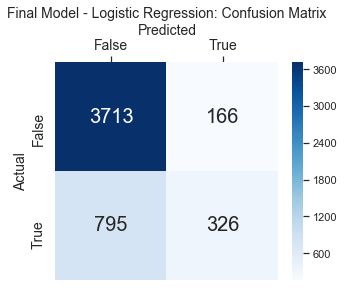

```
Final Model - Logistic Regression: Accuracy =  0.8078

Classification Report
              precision    recall  f1-score   support

           0       0.82      0.96      0.89      3879
           1       0.66      0.29      0.40      1121

    accuracy                           0.81      5000
   macro avg       0.74      0.62      0.64      5000
weighted avg       0.79      0.81      0.78      5000
```

```python
final_preds = lr_best_model.predict(X_final)

# confusion matrix
final_cm = pd.DataFrame(confusion_matrix(y_final, final_preds), columns=np.unique(y_final), index = np.unique(y_test))
final_cm.index.name = 'Actual'
final_cm.columns.name = 'Predicted'

plt.figure(figsize=(5,4))
ax= plt.subplot()
plt.title('Final Model - Logistic Regression: Confusion Matrix', size=14)
sns.heatmap(final_cm, annot=True, ax=ax, fmt = 'g',cmap='Blues', annot_kws={"size": 20});
ax.set_xlabel('Predicted', fontsize=14)
ax.xaxis.set_label_position('top')
ax.xaxis.set_ticklabels(['False', 'True'], fontsize = 14)
ax.xaxis.tick_top()
ax.set_ylabel('Actual', fontsize=14)
ax.yaxis.set_ticklabels(['False', 'True'], fontsize = 14)
plt.show()
print('Final Model - Logistic Regression: Accuracy = ',accuracy_score(y_final, final_preds))
print("\nClassification Report")
print(classification_report(y_final, final_preds))
```

#### Unequal Costs

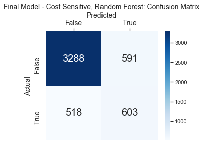

```
Final Model - Cost Sensitive Random Forest: Cost =  3181

Classification Report
              precision    recall  f1-score   support

           0       0.86      0.85      0.86      3879
           1       0.51      0.54      0.52      1121

    accuracy                           0.78      5000
   macro avg       0.68      0.69      0.69      5000
weighted avg       0.78      0.78      0.78      5000
```

```python
finalcs_preds = csrf_best_model.predict(X_final)

# confusion matrix
finalcs_cm = pd.DataFrame(confusion_matrix(y_final, finalcs_preds), columns=np.unique(y_final), index = np.unique(y_test))
finalcs_cm.index.name = 'Actual'
finalcs_cm.columns.name = 'Predicted'

finalcs_cost = a.computecost(finalcs_cm)

plt.figure(figsize=(5,4))
ax= plt.subplot()
plt.title('Final Model - Cost Sensitive, Random Forest: Confusion Matrix', size=14)
sns.heatmap(finalcs_cm, annot=True, ax=ax, fmt = 'g',cmap='Blues', annot_kws={"size": 20});
ax.set_xlabel('Predicted', fontsize=14)
ax.xaxis.set_label_position('top')
ax.xaxis.set_ticklabels(['False', 'True'], fontsize = 14)
ax.xaxis.tick_top()
ax.set_ylabel('Actual', fontsize=14)
ax.yaxis.set_ticklabels(['False', 'True'], fontsize = 14)
plt.show()
print('Final Model - Cost Sensitive Random Forest: Cost = ',finalcs_cost.values.sum())
print("\nClassification Report")
print(classification_report(y_final, finalcs_preds))
```

## Conclusion

Analysing at the equal costs results for the final model; the model generalised well to the previously unseen data, meaning the model did not over-fit the data. The accuracy is slightly less and the recall lower on the positive class than the training data. The accuracy results were fairly consistent across the different models explored, once optimum hyperparameters were chosen; perhaps different pre-processing steps could have increased performance.

If this experiment were to be completed again, the pipeline functionality in the sklearn library could be used, to make the process less onerous. However, the process has been both enlightening and enjoyable.

## References

- Data Visualization using Seaborn: https://towardsdatascience.com/data-visualization-using-seaborn-fc24db95a850
- Dummy Coding: The how and why: https://www.statisticssolutions.com/dummy-coding-the-how-and-why/
- Seaborn: API reference: https://seaborn.pydata.org/api.html
- Sklearn API reference: https://scikit-learn.org/stable/modules/classes.html
- Decision Tree classification: https://www.datacamp.com/community/tutorials/decision-tree-classification-python
- Confusion matrix: https://medium.com/hugo-ferreiras-blog/confusion-matrix-and-other-metrics-in-machine-learning-894688cb1c0a
- Why Random Forest is My Favorite Machine Learning Model: https://towardsdatascience.com/why-random-forest-is-my-favorite-machine-learning-model-b97651fa3706